# Question

Un experimento consiste en medir la elongación de un resorte en función de la fuerza aplicada. En la gráfica se registran los resultados de 107 mediciones realizadas con el mismo resorte.

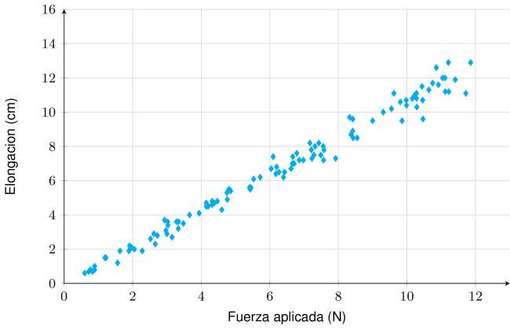

El comportamiento de la elongación respecto a la fuerza aplicada es

## Answerlist

- proporcional y con mayor dispersion cuanto mayor sea la fuerza aplicada.
- proporcional y con mayor dispersion cuanto mayor sea la elongacion.
- no proporcional y con mayor dispersion cuanto mayor sea la fuerza aplicada.
- no proporcional y con mayor dispersion cuanto mayor sea la elongacion.

# Solution

Para analizar el comportamiento de la elongación respecto a la fuerza aplicada, debemos observar dos aspectos clave en la gráfica de dispersión:

**1. Tipo de relación (proporcional vs no proporcional):**

La relación entre la fuerza y la elongación sigue la Ley de Hooke:

$$x = \frac{F}{k}$$

donde $x$ es la elongación, $F$ es la fuerza aplicada y $k$ es la constante del resorte. Esta es una función **proporcional** (proporcionalidad directa). En la gráfica se observa claramente una tendencia rectilínea ascendente.

**2. Patrón de dispersión:**

Observando la gráfica:

- En elongaciones pequeñas (cercanas a 0 cm): los puntos están más concentrados
- En elongaciones grandes (cercanas a 12-14 cm): los puntos muestran mayor variabilidad

**Conclusión:**

El comportamiento es **proporcional** (Ley de Hooke) y **con mayor dispersion cuanto mayor sea la elongacion** (mayor variabilidad en elongaciones grandes).

## Answerlist

# Meta-information

exname: elongacion_resorte_ley_hooke_interpretacion_representacion_n2_v1 extype: schoice exsolution: 0100 exshuffle: TRUE exsection: Estadistica/Graficas de Dispersion